# HW4

Omer Abuhatzira, Eden Malka, Salome Baranes

2025-05-02

Group members:

- Omer Abuhazira 319119988 omer.abuhatzira@mail.huji.ac.il
- Eden Malka 318849940 eden.malka@mail.huji.ac.il
- Salome Baranes 209891183 salome.baranes@mail.huji.ac.il

### Libraries used

```r
# Load necessary libraries
library(data.table)
library(ggplot2)
library(splines)
library(dplyr)
library(tidyr)
library(caret)
library(gridExtra)
library(knitr)
library(kableExtra)
library(pheatmap)
```

### Paths and Data - Data Preparation

```r
library(data.table)

# The read mapping file (from last week's lab)
reads_file <- "C:/Users/97250/Downloads/TCGA-13-0723-01A_lib1_all_chr1.forward"
chr1_reads <- fread(reads_file)
colnames(chr1_reads) <- c("Chrom", "Loc", "FragLen")

# Load and concatenate the full chromosome 1 sequence from 5 parts
load_rda_string <- function(path) {
  obj_name <- load(path)
  get(obj_name)
}

# Load each .rda file
s1 <- load_rda_string("C:/Users/97250/Downloads/chr1_str_0M_50M.rda")
s2 <- load_rda_string("C:/Users/97250/Downloads/chr1_str_50M_100M.rda")
s3 <- load_rda_string("C:/Users/97250/Downloads/chr1_str_100M_150M.rda")
s4 <- load_rda_string("C:/Users/97250/Downloads/chr1_str_150M_200M.rda")
s5 <- load_rda_string("C:/Users/97250/Downloads/chr1_str_200M_end.rda")

# Concatenate to get the full chr1 sequence as a single character string
chr1_seq <- paste0(s1, s2, s3, s4, s5)

# Split into individual bases (A, C, G, T)
chr1_full <- strsplit(chr1_seq, "")[[1]]

# Check length (should be ~250 million)
length(chr1_full)
```

```
## [1] 247249719
```

### Introduction

In this lab, we focus on understanding the relationship between GC content and sequencing coverage. Throughout the analysis, we try different regression models and check how well they explain the coverage based on GC. We also test whether this relationship stays consistent across different regions of the chromosome and under different bin sizes. Along the way, we build functions to make our workflow cleaner and easier to reuse, and we use both plots and summary metrics to compare model performance.

### Before We Begin – Outlier Filtering from our last lab:

### first Filtering

```r
library(data.table)
library(ggplot2)

# Define bin size
bin_size <- 10000
n_bins <- ceiling(length(chr1_full) / bin_size)

# Calculate coverage (number of reads per bin)
bin_breaks <- c(seq(0, length(chr1_full) + bin_size, by = bin_size))
coverage <- hist(chr1_reads$Loc, breaks = bin_breaks, plot = FALSE)$counts

# Prepare dataframe
df <- data.frame(
  Bin = seq_along(coverage),
  Coverage = coverage
)

# Smooth coverage using LOESS
smoothed_line <- loess(Coverage ~ Bin, data = df, span = 0.05)
df$Smoothed <- predict(smoothed_line)

# Calculate residuals
df$Residual <- df$Coverage - df$Smoothed

# Calculate IQR from residuals
Q1 <- quantile(df$Residual, 0.25)
Q3 <- quantile(df$Residual, 0.75)
IQR_val <- Q3 - Q1

upper_threshold <- Q3 + 1.5 * IQR_val
lower_threshold <- Q1 - 1.5 * IQR_val

# Define upper and lower outliers
df$OutlierType <- "None"
df$OutlierType[df$Residual > upper_threshold] <- "Above LOESS"
df$OutlierType[df$Residual < lower_threshold] <- "Below LOESS"

# Create clean dataset without outliers and low coverage for further use
df_clean <- df[df$OutlierType == "None" & df$Coverage >= 5, ]
```

### Second filtering + Ploting + Cubic SPline:

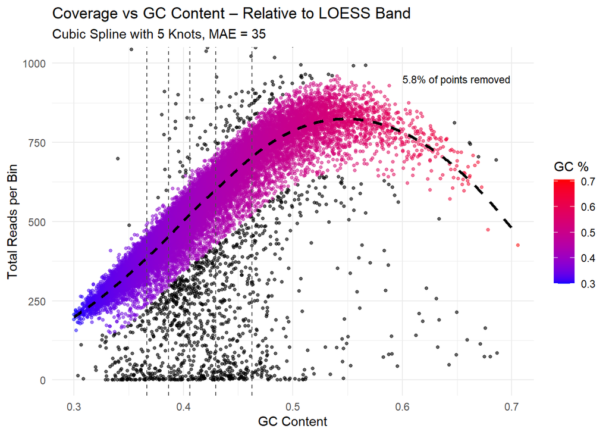

```r
library(splines)
library(dplyr)
library(ggplot2)

# GC Content per bin
GC_per_bin <- numeric(n_bins)
for (i in 1:n_bins) {
  bin <- chr1_full[((i - 1) * bin_size + 1):(i * bin_size)]
  GC_per_bin[i] <- sum(bin %in% c("G", "C")) / bin_size
}

# Create df_model with Coverage + GC_Content
df_model <- data.frame(
  Bin = seq_along(coverage),
  Coverage = coverage,
  GC_Content = GC_per_bin
)

# Compute LOESS and prediction
loess_fit <- loess(Coverage ~ GC_Content, data = df_model, span = 0.5)
df_model$LOESS_Fit <- predict(loess_fit)

# Filter GC_Content >= 0.2
df_model <- df_model %>% filter(GC_Content >= 0.3)

# Remove outliers using IQR method
df_model$Residual <- df_model$Coverage - df_model$LOESS_Fit
iqr_val <- IQR(df_model$Residual, na.rm = TRUE)
q1 <- quantile(df_model$Residual, 0.25, na.rm = TRUE)
q3 <- quantile(df_model$Residual, 0.75, na.rm = TRUE)
lower_bound <- q1 - 3.25 * iqr_val
upper_bound <- q3 + 3.25 * iqr_val

df_clean <- df_model %>%
  filter(Residual >= lower_bound, Residual <= upper_bound)

# Additional filter: remove top 1% most extreme residuals
abs_res <- abs(df_clean$Residual)
threshold_1pct <- quantile(abs_res, 0.98)
df_clean <- df_clean %>% filter(abs(Residual) <= threshold_1pct)

# Define 5 knots explicitly
knots_gc <- quantile(df_clean$GC_Content, probs = seq(0.2, 0.8, length.out = 5))

# Final spline fit with 5 knots
fit <- lm(Coverage ~ bs(GC_Content, knots = knots_gc, degree = 3), data = df_clean)
df_clean$Cubic_Fit <- predict(fit)
mae <- round(mean(abs(df_clean$Coverage - df_clean$Cubic_Fit)), 2)

# Identify removed points
removed_pts <- anti_join(df_model, df_clean, by = c("GC_Content", "Coverage"))

# Calculate percentage of removed points
pct_removed <- round(100 * nrow(removed_pts) / (nrow(removed_pts) + nrow(df_clean)), 1)
label_text <- paste0(pct_removed, "% of points removed")

# Plot with knots
ggplot() +
  geom_point(data = df_model, aes(x = GC_Content, y = Coverage),
             color = "lightgrey", alpha = 0.2, size = 1) +
  geom_point(data = removed_pts, aes(x = GC_Content, y = Coverage),
             color = "black", alpha = 0.6, size = 1) +
  geom_point(data = df_clean, aes(x = GC_Content, y = Coverage, color = GC_Content),
             alpha = 0.5, size = 1) +
  geom_line(data = df_clean, aes(x = GC_Content, y = Cubic_Fit),
            linetype = "dashed", color = "black", size = 1.2) +
  geom_vline(xintercept = knots_gc, linetype = "dashed", color = "gray30") +
  annotate("text", x = 0.6, y = 950, label = label_text, hjust = 0, size = 3) +
  scale_color_gradient(low = "blue", high = "red", name = "GC %") +
  labs(
    title = "Coverage vs GC Content – Relative to LOESS Band",
    subtitle = paste("Cubic Spline with 5 Knots, MAE =", mae),
    x = "GC Content",
    y = "Total Reads per Bin"
  ) +
  coord_cartesian(xlim = c(0.3, 0.7), ylim = c(0, 1000)) +
  theme_minimal()
```

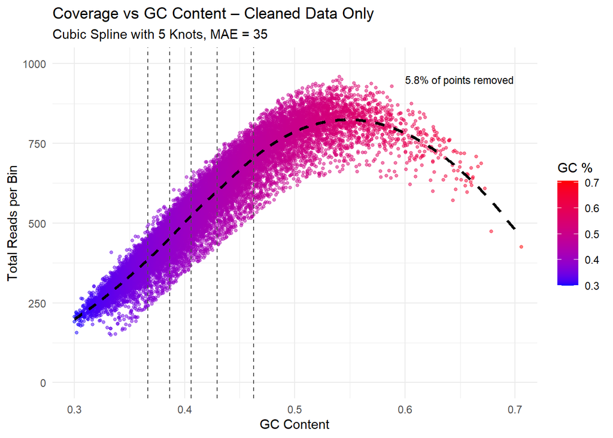

```r
# Cleaned data plot
ggplot(df_clean, aes(x = GC_Content, y = Coverage)) +
  geom_point(aes(color = GC_Content), alpha = 0.5, size = 1) +
  geom_line(aes(y = Cubic_Fit), linetype = "dashed", color = "black", size = 1.2) +
  geom_vline(xintercept = knots_gc, linetype = "dashed", color = "gray30") +
  annotate("text", x = 0.6, y = 950, label = label_text, hjust = 0, size = 3) +
  scale_color_gradient(low = "blue", high = "red", name = "GC %") +
  labs(
    title = "Coverage vs GC Content – Cleaned Data Only",
    subtitle = paste("Cubic Spline with 5 Knots, MAE =", mae),
    x = "GC Content",
    y = "Total Reads per Bin"
  ) +
  coord_cartesian(xlim = c(0.3, 0.7), ylim = c(0, 1000)) +
  theme_minimal()
```

### Outlier Filtering and Model Fitting interpetation:

In the first step, we calculated sequencing coverage across 10,000bp bins and applied a LOESS smoothing function to capture the general trend in coverage along the chromosome. We then computed the residuals and removed bins whose residuals were outside the range defined by **Q1 − 1.5 × IQR** and **Q3 + 1.5 × IQR**. Additionally, bins with very low coverage (less than 5 reads) were filtered out.

In the second step, we refined the filtering process to better capture the relationship between GC content and sequencing coverage. First, we excluded bins with low GC values, keeping only those with GC content above 0.3. Then, we fitted a LOESS model to the data and calculated the residuals. We used the IQR method again, but this time with a wider range (**±3.25 × IQR**) to filter out more extreme points that don’t follow the LOESS trend well.

Additionally, based on visual inspection, we noticed that a few extreme points still remained and distorted the fit. To address this, we removed the top 2% most extreme residuals. Now we can start.

### Part a - Train/Test Split and Detecting Overfitting

Before diving into training the model on different sample sizes, we wanted to first get a clear picture of how the model performs when trained on the full training data (80%) and tested on a separate test set (20%). We used a stratified split based on GC content to make sure the GC distribution stays similar in both sets. Then, we fit our original cubic spline model (with the same fixed knots as before) on the training data, and compared its predictions to the actual coverage values in both train and test sets.

```r
library(dplyr)
library(ggplot2)
library(caret)
library(splines)

set.seed(123)

# Split data into Train/Test

# Create GC bins for stratified sampling
df_clean <- df_clean %>%
  mutate(GC_Bin = cut(GC_Content, breaks = seq(0.2, 0.7, by = 0.05), include.lowest = TRUE))

# Perform stratified split based on GC distribution
train_index <- createDataPartition(df_clean$GC_Bin, p = 0.8, list = FALSE)

train_data <- df_clean[train_index, ]
test_data <- df_clean[-train_index, ]

cat("Train size:", nrow(train_data), "(80%)\n")
```

```
## Train size: 16941 (80%)
```

```r
cat("Test size:", nrow(test_data), "(20%)\n")
```

```
## Test size: 4230 (20%)
```

```r
# Fit spline model on Train data

fit_train <- lm(Coverage ~ bs(GC_Content, knots = knots_gc, degree = 3), data = train_data)

# Predict on Train data
train_data$Predicted <- predict(fit_train, newdata = train_data)

# Predict on Test data

test_data$Predicted <- predict(fit_train, newdata = test_data)

# Calculate MAE

mae_train <- mean(abs(train_data$Coverage - train_data$Predicted))
mae_test <- mean(abs(test_data$Coverage - test_data$Predicted))

# Display MAE results
mae_results <- data.frame(
  Set = c("Train", "Test"),
  MAE = c(mae_train, mae_test)
)

print(mae_results)
```

```
##     Set      MAE
## 1 Train 35.05804
## 2  Test 34.84056
```

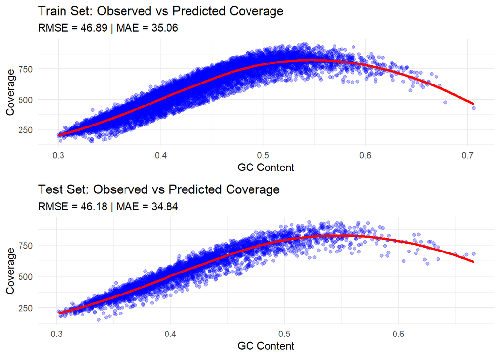

```r
library(dplyr)
library(ggplot2)
library(gridExtra)

# Calculate RMSE
rmse_train <- sqrt(mean((train_data$Coverage - train_data$Predicted)^2))
rmse_test <- sqrt(mean((test_data$Coverage - test_data$Predicted)^2))

# Plot for Train
p_train <- ggplot(train_data, aes(x = GC_Content, y = Coverage)) +
  geom_point(alpha = 0.3, color = "blue") +
  geom_line(aes(y = Predicted), color = "red", size = 1.2) +
  labs(
    title = paste("Train Set: Observed vs Predicted Coverage"),
    subtitle = paste("RMSE =", round(rmse_train, 2), "| MAE =", round(mae_train, 2)),
    x = "GC Content",
    y = "Coverage",
    color = "Legend"
  ) +
  theme_minimal()

# Plot for Test
p_test <- ggplot(test_data, aes(x = GC_Content, y = Coverage)) +
  geom_point(alpha = 0.3, color = "blue") +
  geom_line(aes(y = Predicted), color = "red", size = 1.2) +
  labs(
    title = paste("Test Set: Observed vs Predicted Coverage"),
    subtitle = paste("RMSE =", round(rmse_test, 2), "| MAE =", round(mae_test, 2)),
    x = "GC Content",
    y = "Coverage",
    color = "Legend"
  ) +
  theme_minimal()

# Show both plots together
gridExtra::grid.arrange(p_train, p_test, ncol = 1)
```

### Interpretation of Results

The two plots show the observed versus predicted coverage for both the training and test sets. The red curve in both plots represents the same cubic spline model we fit earlier using the training data only. Visually, the model seems to capture the main trend of the data quite well in both sets, with a similar shape and no major discrepancies. The RMSE and MAE values are also very close between train and test, which suggests that the model generalizes well and is not overfitting at this point. This result gives us confidence to move forward and test how model performance behaves as we reduce the training size.

### Visualizing GC Content Distribution After Train/Test Split

To make sure our train-test split is fair, we visualized the GC content distribution in both sets. Since the model is sensitive to GC content, it’s important that the distribution remains consistent across the split.

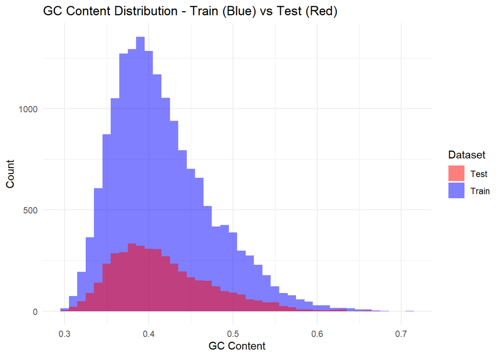

```r
ggplot(df_clean, aes(x = GC_Content)) +
  geom_histogram(data = train_data, aes(fill = "Train"), alpha = 0.5, binwidth = 0.01) +
  geom_histogram(data = test_data, aes(fill = "Test"), alpha = 0.5, binwidth = 0.01) +
  labs(title = "GC Content Distribution - Train (Blue) vs Test (Red)",
       x = "GC Content",
       y = "Count",
       fill = "Dataset") +
  scale_fill_manual(values = c("Train" = "blue", "Test" = "red")) +
  theme_minimal()
```

### Interpetation

The histogram confirms that the GC content is distributed similarly in both the training set (blue) and the test set (red). While the test set has fewer observations, the overall shape and spread of GC values is consistent.

### Investigating Overfitting by Varying Training Sample Size

To address the question of overfitting, we simulated how the model behaves when trained on varying sample sizes. Specifically, we drew multiple random subsets of different sizes from the original training set (ranging from 3% to 90%) and evaluated the model’s Mean Absolute Error (MAE) Gap between the the training and test sets, along with its standard deviation. Our goal is to see when overfitting tends to occur.

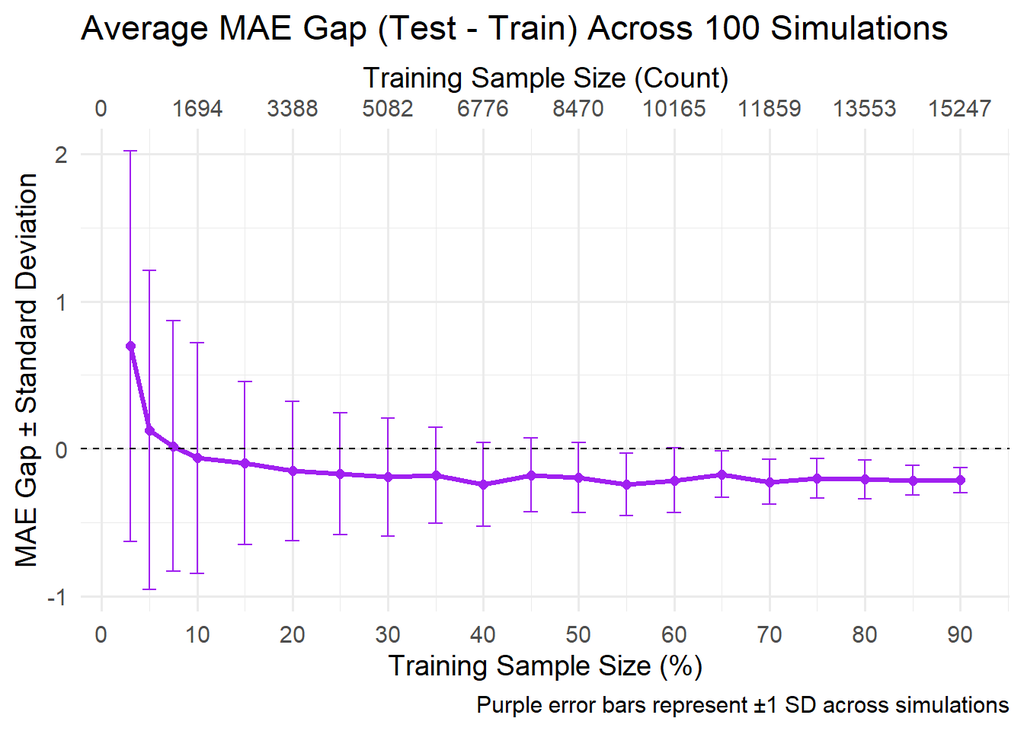

```r
library(caret)
library(ggplot2)
library(dplyr)

set.seed(123)

# proportions include small sizes
proportions <- c(0.03, 0.05, 0.075, 0.10, seq(0.15, 0.9, by = 0.05))
n_train <- nrow(train_data)
n_simulations <- 100

results <- data.frame()

for (p in proportions) {
  mae_gaps <- numeric(n_simulations)

  for (i in 1:n_simulations) {
    sub_indices <- sample(seq_len(n_train), size = floor(p * n_train))
    sub_train <- train_data[sub_indices, ]

    model <- lm(Coverage ~ bs(GC_Content, knots = knots_gc, degree = 3), data = sub_train)

    mae_train <- mean(abs(sub_train$Coverage - predict(model, newdata = sub_train)))
    mae_test  <- mean(abs(test_data$Coverage - predict(model, newdata = test_data)))

    mae_gaps[i] <- mae_test - mae_train
  }

  results <- rbind(results, data.frame(
    Train_Percent = round(p * 100, 2),
    Sample_Size = floor(p * n_train),
    MAE_Gap_Mean = mean(mae_gaps),
    MAE_Gap_SD = sd(mae_gaps)
  ))
}

# Improved axis breaks for readability
ggplot(results, aes(x = Train_Percent, y = MAE_Gap_Mean)) +
  geom_line(color = "purple", size = 1.2) +
  geom_point(size = 2, color = "purple") +
  geom_errorbar(aes(ymin = MAE_Gap_Mean - MAE_Gap_SD,
                    ymax = MAE_Gap_Mean + MAE_Gap_SD),
                width = 1.5, color = "purple") +
  geom_hline(yintercept = 0, linetype = "dashed") +
  scale_x_continuous(
    breaks = seq(0, 100, by = 10),
    name = "Training Sample Size (%)",
    sec.axis = dup_axis(
      trans = ~ round(. / 100 * n_train),
      breaks = round(seq(0, 100, by = 10) / 100 * n_train),
      name = "Training Sample Size (Count)"
    )
  ) +
  labs(
    title = "Average MAE Gap (Test - Train) Across 100 Simulations",
    y = "MAE Gap ± Standard Deviation",
    caption = "Purple error bars represent ±1 SD across simulations"
  ) +
  theme_minimal(base_size = 14)
```

### Overfitting Analysis Based on Training Set Percentage

### At What Train Size Does Overfitting Begin?

The graph shows the average MAE gap (Test - Train) for different training set sizes. At very small sample sizes (3%–5%), the model tends to overfit the training data, as indicated by a positive MAE gap — meaning the test error is significantly higher than the training error. This is accompanied by large standard deviations, showing that model performance is unstable in such small samples.

As the training set size increases beyond approximately 7.5%–10% (around 1700 examples), the MAE gap becomes negative and stabilizes - the model generalizes well to the test set. The gap remains consistently close to zero or slightly negative as the training size continues to grow, and the error bars become narrower, indicating more reliable and consistent behavior.

In conclusion, there appears to be a tendency toward overfitting in training sets smaller than ~7.5%, This happens because small training sets don’t capture the full variability of the data, so the model ends up fitting noise instead of learning the true pattern.

### Part b - Comparing Coverage Models: G vs. C vs. G+C

To better understand what drives coverage, we fit three separate cubic spline models using the same modeling approach we’ve used so far: one model based on G content, one on C content, and one using the combined G+C content. All models were fitted using 5 knots based on the quantiles of the predictor variable and the same cleaned dataset to ensure a fair comparison. This allowed us to assess which predictor provides a better explanation of the variation in coverage, based on both R² and MAE metrics.

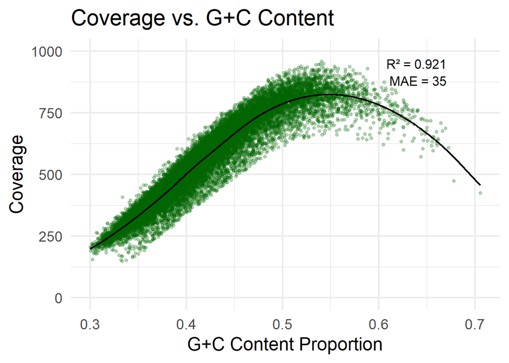

```r
df_gc <- df_clean

# Add G and C columns by counting bases from chr1_full per bin
df_gc$G <- NA
df_gc$C <- NA

for (i in seq_len(nrow(df_gc))) {
  bin_index <- df_gc$Bin[i]
  bin_bases <- chr1_full[((bin_index - 1) * bin_size + 1):(bin_index * bin_size)]

  df_gc$G[i] <- sum(bin_bases == "G") / bin_size
  df_gc$C[i] <- sum(bin_bases == "C") / bin_size
}

# Define knots for each predictor
knots_g   <- quantile(df_gc$G, probs = seq(0.2, 0.8, length.out = 5))
knots_c   <- quantile(df_gc$C, probs = seq(0.2, 0.8, length.out = 5))
knots_gc  <- quantile(df_gc$G + df_gc$C, probs = seq(0.2, 0.8, length.out = 5))

# Fit cubic spline models
fit_g_spline  <- lm(Coverage ~ bs(G,        knots = knots_g,  degree = 3), data = df_gc)
fit_c_spline  <- lm(Coverage ~ bs(C,        knots = knots_c,  degree = 3), data = df_gc)
fit_gc_spline <- lm(Coverage ~ bs(G + C,    knots = knots_gc, degree = 3), data = df_gc)

# Predict values
df_gc$Pred_G   <- predict(fit_g_spline)
df_gc$Pred_C   <- predict(fit_c_spline)
df_gc$Pred_GC  <- predict(fit_gc_spline)

# Calculate metrics
r2_g   <- round(summary(fit_g_spline)$r.squared, 3)
r2_c   <- round(summary(fit_c_spline)$r.squared, 3)
r2_gc  <- round(summary(fit_gc_spline)$r.squared, 3)

mae_g  <- round(mean(abs(df_gc$Coverage - df_gc$Pred_G)), 2)
mae_c  <- round(mean(abs(df_gc$Coverage - df_gc$Pred_C)), 2)
mae_gc <- round(mean(abs(df_gc$Coverage - df_gc$Pred_GC)), 2)

# Plotting function
plot_spline_model <- function(x_vals, pred_vals, label, color, r2, mae) {
  df_plot <- data.frame(
    x = x_vals,
    y = df_gc$Coverage,
    yhat = pred_vals
  )

  ggplot(df_plot, aes(x = x, y = y)) +
    geom_point(alpha = 0.3, color = color, size = 1.2) +
    geom_line(aes(y = yhat), color = "black", linewidth = 0.8) +
    coord_cartesian(ylim = c(0, 1000)) +
    labs(
      title = paste("Coverage vs.", label),
      x = paste(label, "Proportion"),
      y = "Coverage"
    ) +
    annotate("text", x = max(x_vals, na.rm = TRUE) * 0.95, y = 950,
             label = paste0("R² = ", r2), hjust = 1, size = 4.5) +
    annotate("text", x = max(x_vals, na.rm = TRUE) * 0.95, y = 880,
             label = paste0("MAE = ", mae), hjust = 1, size = 4.5) +
    theme_minimal(base_size = 18)
}

# Generate plots
plot_spline_model(df_gc$G + df_gc$C, df_gc$Pred_GC, "G+C Content", "darkgreen", r2_gc, mae_gc)
```

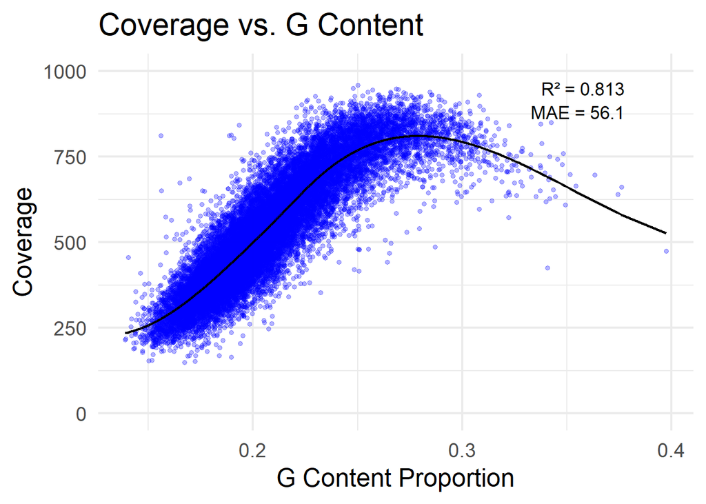

```r
plot_spline_model(df_gc$G, df_gc$Pred_G, "G Content", "blue", r2_g, mae_g)
```

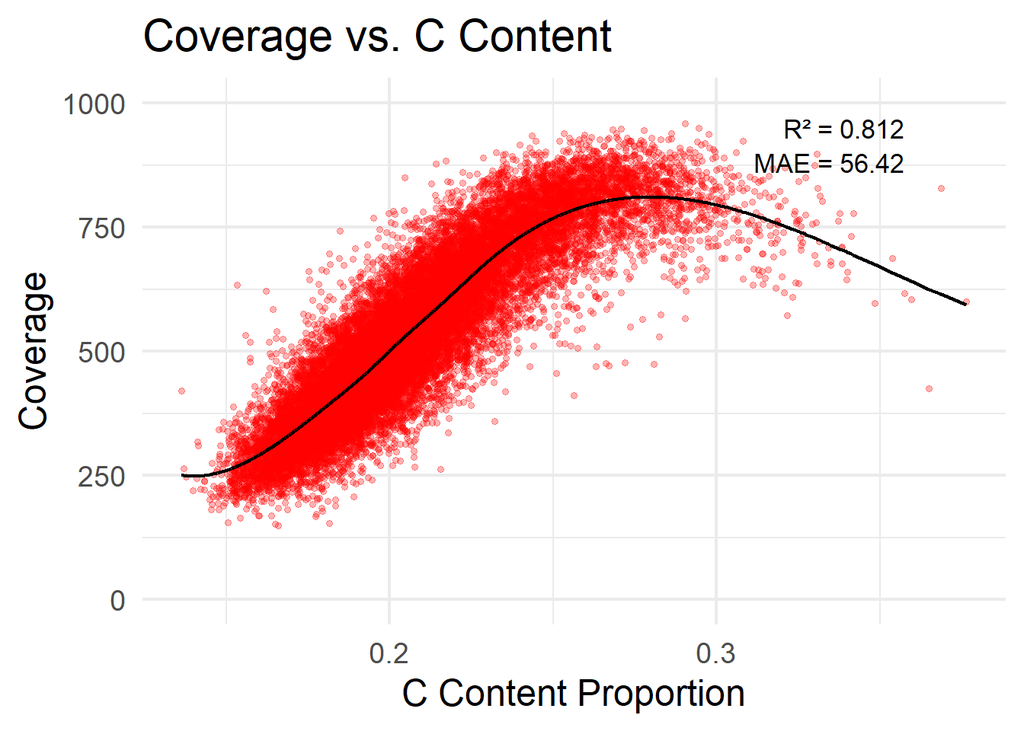

```r
plot_spline_model(df_gc$C, df_gc$Pred_C, "C Content", "red", r2_c, mae_c)
```

#### Comparative Analysis: Coverage vs. G+C, G, and C Content

Additionally, the scatter plots for G and C show more dispersion around the fitted curve, suggesting greater variability and weaker model fit when using each base separately.

This suggests that coverage is better explained by the total GC content rather than the individual contributions of G or C alone.

#### MAE Gap (Test - Train) by Sample Size and cubic spline

In this section, we explore how the choice of predictor (G, C, or G+C) impacts model performance across different training sample sizes. For each predictor, we repeatedly fit a cubic spline model with 5 knots, using manually defined knot positions based on quantiles. We test sample sizes of 500, 1000, 2000, and 4000, and for each size we run 100 simulations where the data is split into 80% training and 20% testing.

In each simulation, we calculate the mean absolute error (MAE) for both the train and test sets and compute the gap between them (Test MAE - Train MAE).

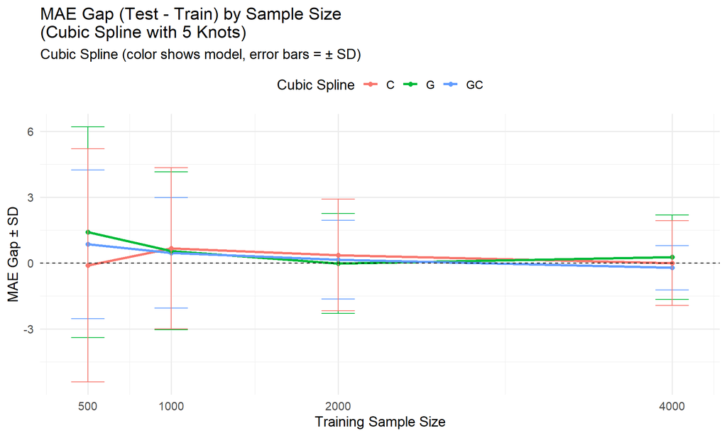

```r
library(dplyr)
library(ggplot2)
library(caret)
library(splines)

set.seed(42)

# Sample sizes and simulations
sample_sizes <- c(500, 1000, 2000, 4000)
n_simulations <- 100

# Define knots once — use df_gc which includes G and C
knots_gc <- quantile(df_gc$G + df_gc$C, probs = seq(0.2, 0.8, length.out = 5))
knots_g  <- quantile(df_gc$G, probs = seq(0.2, 0.8, length.out = 5))
knots_c  <- quantile(df_gc$C, probs = seq(0.2, 0.8, length.out = 5))

# Store results
results <- data.frame()

for (predictor in c("GC", "G", "C")) {
  for (size in sample_sizes) {
    mae_gaps <- numeric(n_simulations)

    for (i in 1:n_simulations) {
      df_sample <- df_gc %>% sample_n(size)  # sample from df_gc, not df_clean
      train_index <- createDataPartition(df_sample$Coverage, p = 0.8, list = FALSE)
      train_data <- df_sample[train_index, ]
      test_data  <- df_sample[-train_index, ]

      # Choose model
      if (predictor == "GC") {
        model <- lm(Coverage ~ bs(G + C, knots = knots_gc, degree = 3), data = train_data)
      } else if (predictor == "G") {
        model <- lm(Coverage ~ bs(G, knots = knots_g, degree = 3), data = train_data)
      } else {
        model <- lm(Coverage ~ bs(C, knots = knots_c, degree = 3), data = train_data)
      }

      train_pred <- predict(model, newdata = train_data)
      test_pred  <- predict(model, newdata = test_data)

      mae_train <- mean(abs(train_data$Coverage - train_pred))
      mae_test  <- mean(abs(test_data$Coverage - test_pred))
      mae_gaps[i] <- mae_test - mae_train
    }

    results <- rbind(results, data.frame(
      Predictor = predictor,
      SampleSize = size,
      MAE_Gap_Mean = mean(mae_gaps),
      MAE_Gap_SD = sd(mae_gaps)
    ))
  }
}

# Improved plot with dodged error bars
dodge <- position_dodge(width = 200)

ggplot(results, aes(x = SampleSize, y = MAE_Gap_Mean, color = Predictor)) +
  geom_line(linewidth = 1.2) +
  geom_point(size = 2) +
  geom_errorbar(aes(ymin = MAE_Gap_Mean - MAE_Gap_SD,
                    ymax = MAE_Gap_Mean + MAE_Gap_SD),
                width = 200) +
  geom_hline(yintercept = 0, linetype = "dashed") +
  scale_x_continuous(breaks = sample_sizes) +
  labs(
    title = "MAE Gap (Test - Train) by Sample Size\n(Cubic Spline with 5 Knots)",
    subtitle = "Cubic Spline (color shows model, error bars = ± SD)",
    x = "Training Sample Size",
    y = "MAE Gap ± SD",
    color = "Cubic Spline"
  ) +
  theme_minimal(base_size = 14) +
  theme(legend.position = "top")
```

#### Interpretation: MAE Gap (Test - Train) by Sample Size and Cubic Spline

The plot shows the MAE gap between test and train sets for each predictor across increasing sample sizes. At smaller sample sizes (500 and 1000), the G predictor shows a large positive gap, suggesting strong overfitting — the model fits the training data well but generalizes poorly. As the sample size grows, the gap narrows and even becomes slightly negative at 2000, indicating potential underfitting. The GC predictor performs more consistently, with a relatively small gap across all sample sizes, indicating better generalizability. The C predictor maintains a moderate and stable gap, but performs slightly worse than GC. Overall, the GC model demonstrates the most balanced performance with less overfitting, especially as sample size increases.

### Summary

As the sample size increases, the MAE gap narrows for all predictors, but GC remains the most stable and balanced. This supports our earlier finding that combining G and C provides a more reliable estimate of coverage, especially when data is limited.

```r
library(dplyr)
library(tidyr)
library(kableExtra)

# Table of MAE gaps by predictor and sample size
mae_gap_table <- results %>%
  select(Predictor, SampleSize, MAE_Gap_Mean) %>%
  pivot_wider(names_from = Predictor, values_from = MAE_Gap_Mean, names_prefix = "MAE_Gap_") %>%
  rename(
    `MAE Gap (GC)` = MAE_Gap_GC,
    `MAE Gap (G)` = MAE_Gap_G,
    `MAE Gap (C)` = MAE_Gap_C
  )

# Display formatted table
mae_gap_table %>%
  kable(caption = "Average MAE Gap (Test - Train) by Predictor and Sample Size",
        align = 'c', format = "html") %>%
  kable_styling(full_width = FALSE, position = "center")
```

Average MAE Gap (Test - Train) by Predictor and Sample Size

| SampleSize | MAE Gap (GC) | MAE Gap (G) | MAE Gap (C) |
| --- | --- | --- | --- |
| 500 | 0.8583633 | 1.4054034 | -0.1014641 |
| 1000 | 0.4670304 | 0.5535725 | 0.6751348 |
| 2000 | 0.1556464 | -0.0169980 | 0.3697930 |
| 4000 | -0.2106641 | 0.2676317 | 0.0047394 |

#### Interpretation: Train and Test MAE Gap by Predictor and Sample Size

The table shows the average MAE gap (Test MAE - Train MAE) across different predictors and training sample sizes. A positive gap suggests overfitting (better performance on train than test), while a negative gap may indicate underfitting or good generalization.

For small sample sizes (e.g., 500), the G predictor shows the largest overfitting with a gap of ~1.4, while the GC predictor shows a smaller gap (~0.86), and C shows almost no gap. As the sample size increases, the gaps for all predictors shrink toward zero, showing improved generalization.

### Cross-Region Generalization: Can One GC-Coverage Model Fit All?

In this section, we investigate whether the relationship between GC content and sequencing coverage is consistent across different regions of the chromosome. To do this, we divided the chromosome into **five equal-sized regions** based on the number of genomic bins. Each region contains approximately the same number of bins, ensuring that the comparison is balanced and not biased by region size.

### MAE heatmap

To visualize how well models trained in one region perform across all regions, we use the following MAE heatmap to highlight the differences in prediction accuracy between region pairs.

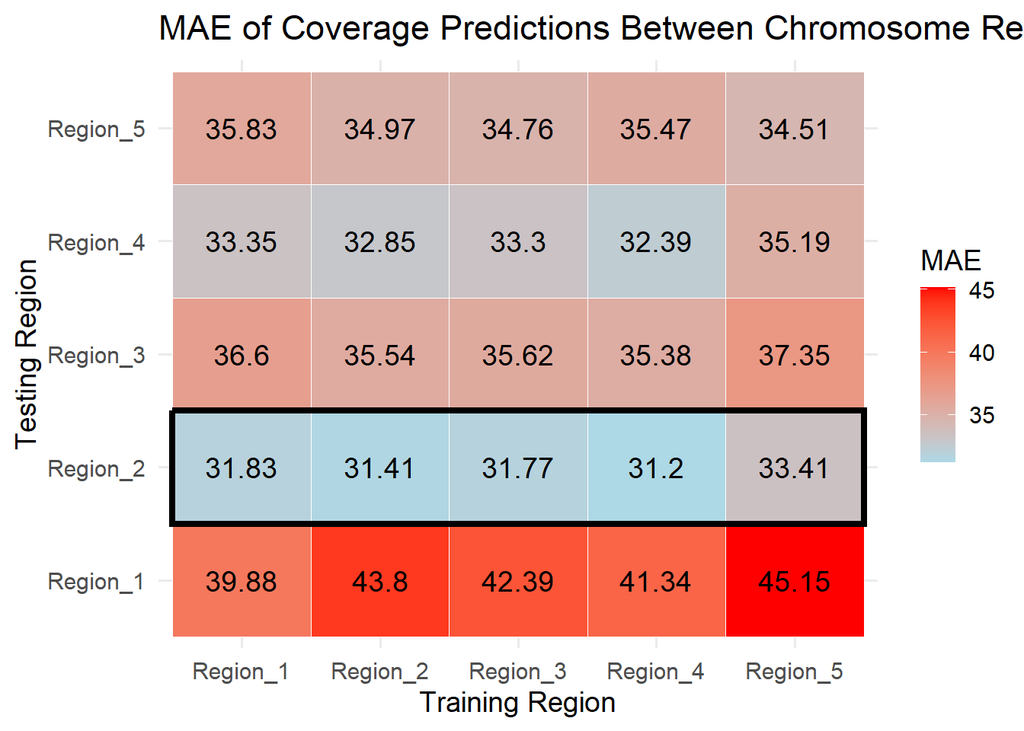

```r
# Ensure chromosome is divided into 5 regions
df_clean$Region <- cut(df_clean$Bin, breaks = 5, labels = paste0("Region_", 1:5))

# Create a table of MAE results for all region combinations
region_ids <- sort(unique(df_clean$Region))
region_cv_results <- data.frame()

for (train_region in region_ids) {
  for (test_region in region_ids) {

    # Filter training and testing data for each region
    train_data <- df_clean %>% filter(Region == train_region)
    test_data  <- df_clean %>% filter(Region == test_region)

    # Fit spline model only on the training region
    model <- lm(Coverage ~ bs(GC_Content, knots = knots_gc, degree = 3), data = train_data)

    # Predict coverage on the test region
    preds <- predict(model, newdata = test_data)

    # Calculate Mean Absolute Error (MAE) on the test data
    mae <- round(mean(abs(test_data$Coverage - preds)), 2)

    # Store results in a combined data frame
    region_cv_results <- rbind(region_cv_results, data.frame(
      TrainRegion = train_region,
      TestRegion = test_region,
      MAE = mae
    ))
  }
}

# Plot heatmap of MAE values
region_cv_results$highlight <- region_cv_results$TestRegion == "Region_2"

# Plot with black border for Region_2 test row
# Plot the heatmap normally
ggplot(region_cv_results, aes(x = TrainRegion, y = TestRegion, fill = MAE)) +
  geom_tile(color = "white") +
  geom_text(aes(label = MAE), size = 5, color = "black") +
  scale_fill_gradient(low = "lightblue", high = "red") +

  # Add full black rectangle manually around the row of Region_2
  geom_rect(
    data = NULL,
    aes(xmin = 0.5, xmax = 5.5, ymin = which(levels(region_ids) == "Region_2") - 0.5,
        ymax = which(levels(region_ids) == "Region_2") + 0.5),
    color = "black",
    fill = NA,
    linewidth = 1.5
  ) +

  labs(
    title = "MAE of Coverage Predictions Between Chromosome Regions",
    x = "Training Region",
    y = "Testing Region",
    fill = "MAE"
  ) +
  theme_minimal(base_size = 14)
```

### Interpretation of the Full Cross-Region MAE Matrix

The heatmap shows the Mean Absolute Error (MAE) values for every pair of training and testing regions. Each cell represents how well a model trained on one region predicts coverage in another. Lighter cells indicate better prediction performance, while darker red cells highlight regions that are harder to model accurately.

#### Region 2 – Easiest Region to Predict

**Conclusion**: the relationship between GC content and coverage is not identical across all regions, so it’s better to fit separate models for each region rather than using a single global function.

### MAE GAP Plot:

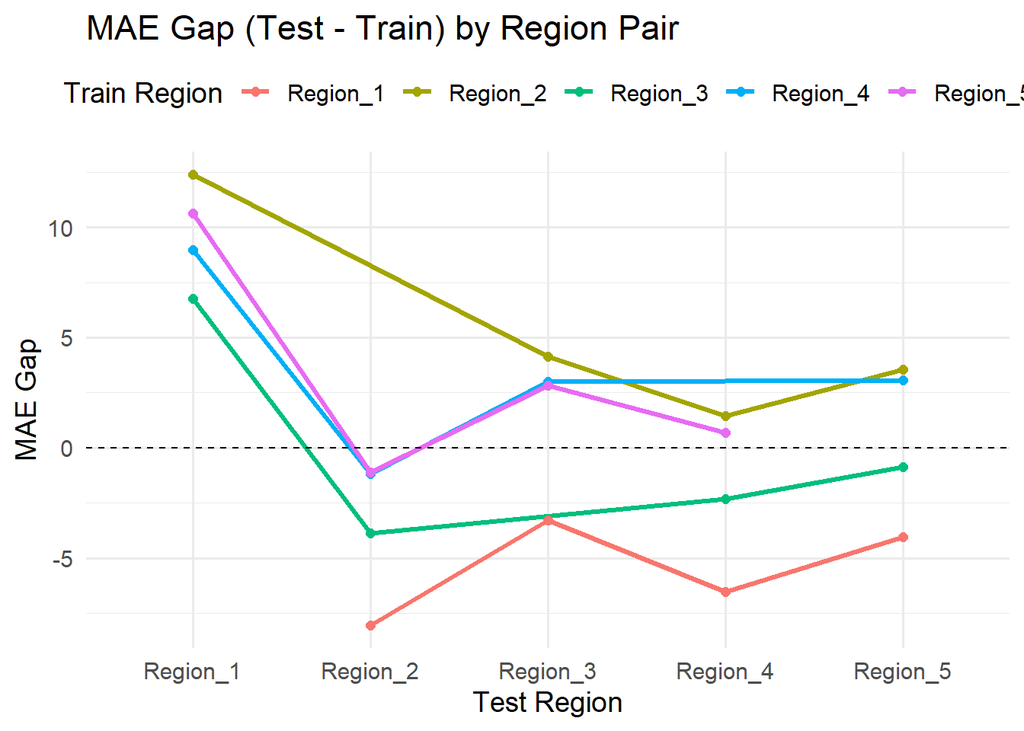

```r
library(dplyr)
library(ggplot2)

# Create region pairs and compute gap
mae_gap_df <- region_cv_results %>%
  group_by(TrainRegion, TestRegion) %>%
  summarize(MAE = mean(MAE), .groups = "drop") %>%
  group_by(TrainRegion) %>%
  mutate(Train_MAE = MAE[TestRegion == TrainRegion]) %>%
  ungroup() %>%
  filter(TestRegion != TrainRegion) %>%
  mutate(MAE_Gap = MAE - Train_MAE)

# Plot with legend on top
ggplot(mae_gap_df, aes(x = TestRegion, y = MAE_Gap, group = TrainRegion, color = TrainRegion)) +
  geom_line(linewidth = 1.2) +
  geom_point(size = 2) +
  geom_hline(yintercept = 0, linetype = "dashed") +
  labs(
    title = "MAE Gap (Test - Train) by Region Pair",
    x = "Test Region",
    y = "MAE Gap",
    color = "Train Region"
  ) +
  theme_minimal(base_size = 14) +
  theme(legend.position = "top")
```

### Interpretation

The graph presents the **MAE gaps** between test and train performance for each region pair.  
A **positive gap** indicates that the model performs **worse on the test region** compared to the region it was trained on, whereas a **negative gap** implies the model actually performed **better on the test region** than on its own training data.

### Cross-Region Generalization - Train: Region 2

Here, we train a spline regression model using only data from Region 2 and evaluate how well it predicts coverage in each of the other regions.

This focused analysis helps us better understand the strengths and limitations of Region 2 as a basis for modeling coverage across the chromosome.

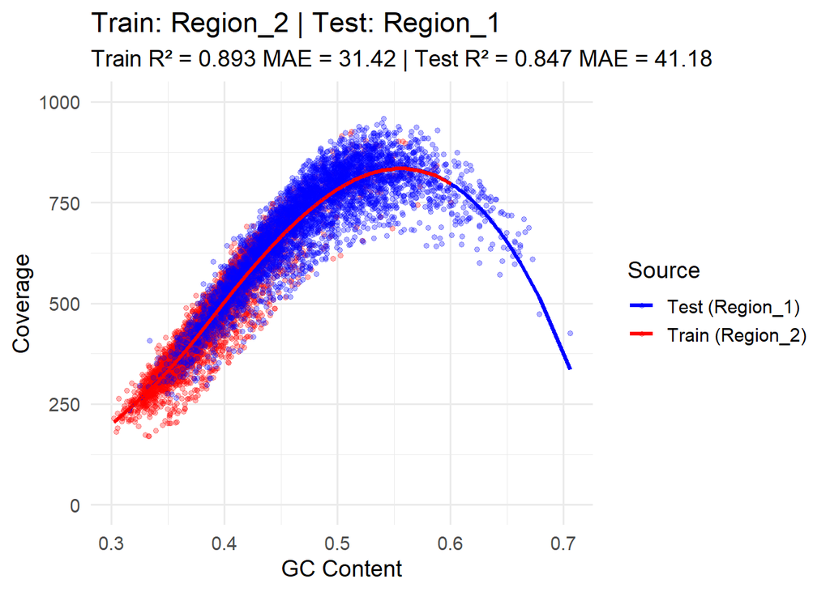

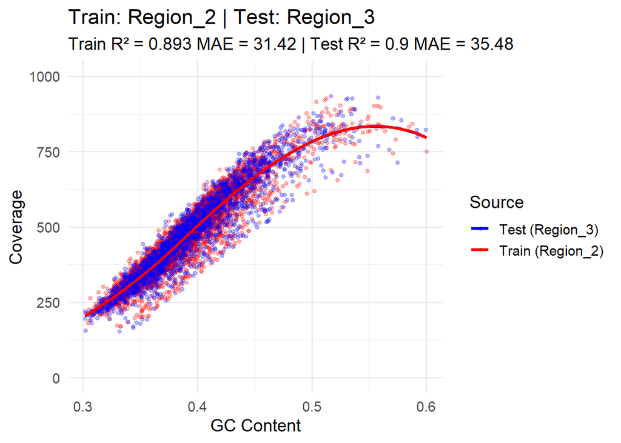

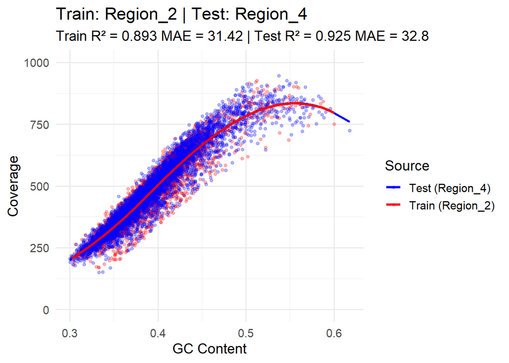

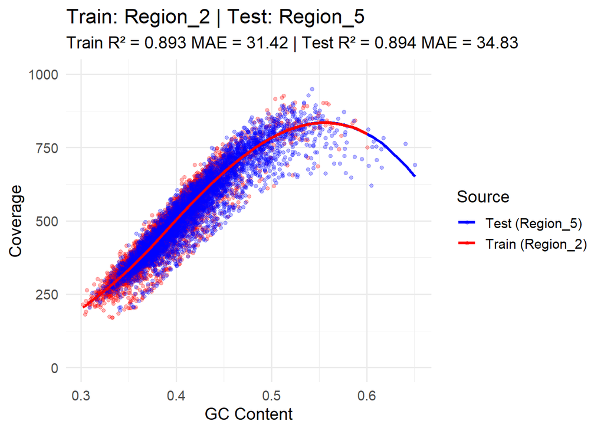

```r
library(dplyr)
library(ggplot2)
library(splines)

# Divide chromosome into 5 regions by bin
n_regions <- 5
df_clean$Region <- cut(df_clean$Bin, breaks = n_regions, labels = paste0("Region_", 1:n_regions))

# Choose one training region
train_region <- "Region_2"
train_data <- df_clean %>% filter(Region == train_region)

# Fit model on train region
model <- lm(Coverage ~ bs(GC_Content, df = 5), data = train_data)
train_data$Predicted <- predict(model, newdata = train_data)

# Loop over all test regions and generate a plot for each
unique_regions <- levels(df_clean$Region)

for (test_region in unique_regions) {

  # Skip if it's the same as the training region
  if (test_region == train_region) next

  # Select test region
  test_data <- df_clean %>% filter(Region == test_region)
  test_data$Predicted <- predict(model, newdata = test_data)

  # Combine data
  plot_df <- bind_rows(
    train_data %>% mutate(Source = paste0("Train (", train_region, ")")),
    test_data %>% mutate(Source = paste0("Test (", test_region, ")"))
  )

  # Calculate metrics
  mae_train <- mean(abs(train_data$Coverage - train_data$Predicted))
  mae_test  <- mean(abs(test_data$Coverage - test_data$Predicted))
  r2_train <- round(summary(lm(train_data$Coverage ~ train_data$Predicted))$r.squared, 3)
  r2_test  <- round(summary(lm(test_data$Coverage ~ test_data$Predicted))$r.squared, 3)

  # Plot
  p <- ggplot(plot_df, aes(x = GC_Content, y = Coverage, color = Source)) +
    geom_point(alpha = 0.3, size = 1.2) +
    geom_line(aes(y = Predicted), size = 1.1) +
    scale_color_manual(values = c("blue", "red")) +
    coord_cartesian(ylim = c(0, 1000)) +
    labs(
      title = paste("Train:", train_region, "| Test:", test_region),
      subtitle = paste("Train R² =", r2_train, "MAE =", round(mae_train, 2),
                       "| Test R² =", r2_test, "MAE =", round(mae_test, 2)),
      x = "GC Content",
      y = "Coverage"
    ) +
    theme_minimal(base_size = 14)

  print(p)  # Display the plot for this region
}
```